# JHU4

bhaskar

*Exploratory graphs* 1. univariate 2. bi variate 3. multivariate

Exploratory statistics 1. Five number summary 2. variance 3. covariance correlation 4. quantiles

Exploratory graphing system 1. base

```r
library(datasets)
head(airquality)
```

```
##   Ozone Solar.R Wind Temp Month Day
## 1    41     190  7.4   67     5   1
## 2    36     118  8.0   72     5   2
## 3    12     149 12.6   74     5   3
## 4    18     313 11.5   62     5   4
## 5    NA      NA 14.3   56     5   5
## 6    28      NA 14.9   66     5   6
```

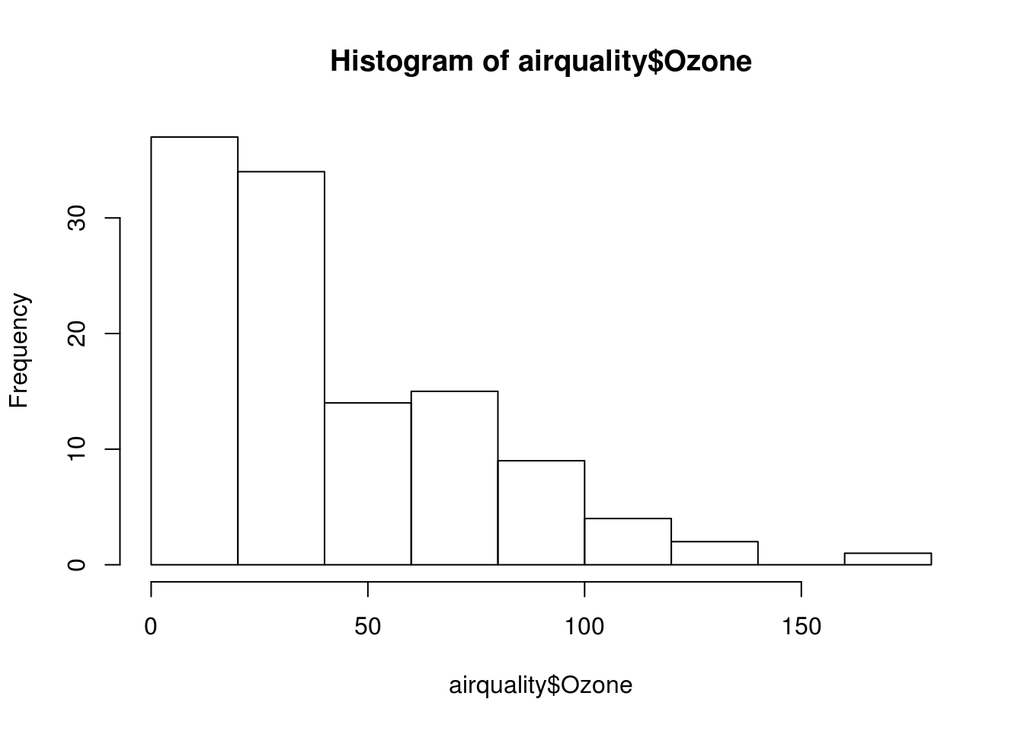

```r
hist(airquality$Ozone)
```

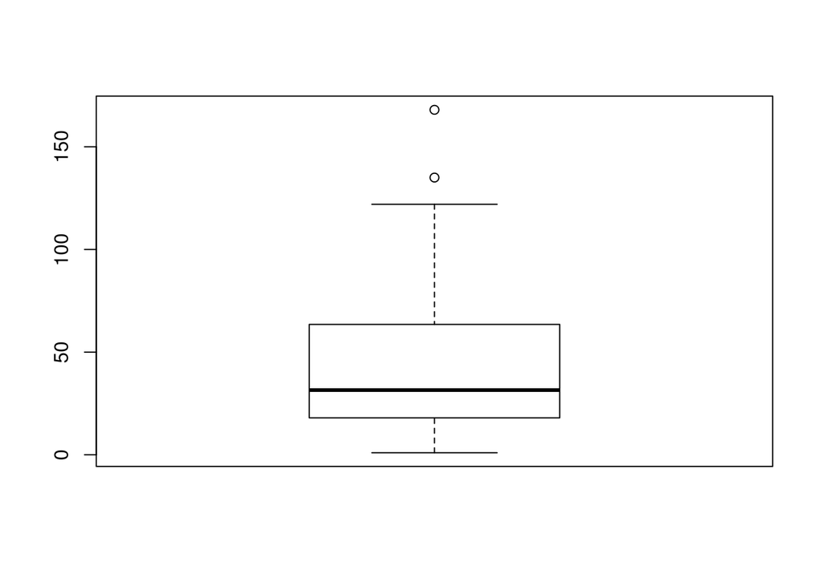

```r
boxplot((airquality$Ozone))
```

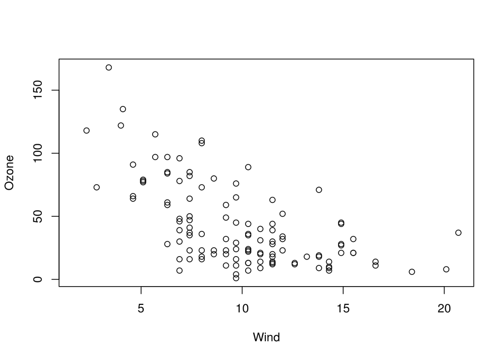

```r
with(airquality,plot(Wind,Ozone))
```

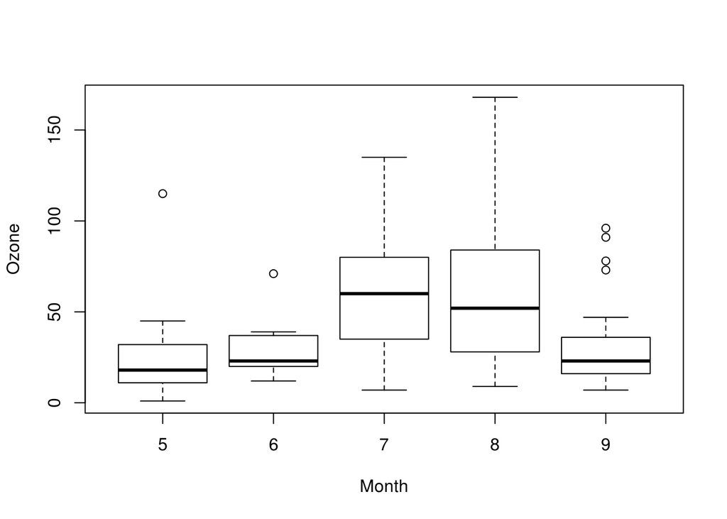

```r
airquality = transform(airquality,Month=as.factor(Month))
boxplot(Ozone~Month,airquality,xlab="Month",ylab="Ozone")
```

**important params** *pch,lwd,lty,col,xlab,ylab* **important par() params** *mar,mfow,mfcol,oma,bg,las* *plot,lines,points,title,mtext,text,axis*

### **base**

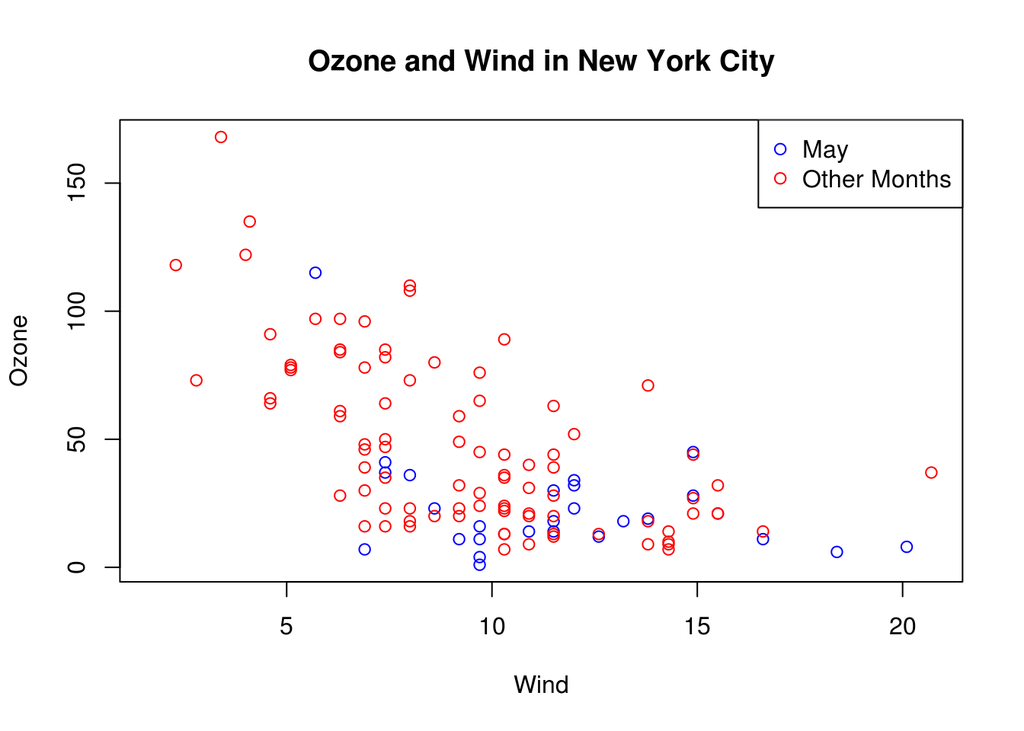

```r
with(airquality, plot(Wind, Ozone, main = "Ozone and Wind in New York City",
    type = "n"))
with(subset(airquality, Month == 5), points(Wind, Ozone, col = "blue"))
with(subset(airquality, Month != 5), points(Wind, Ozone, col = "red"))
legend("topright", pch = 1, col = c("blue", "red"), legend = c("May", "Other Months"))
```

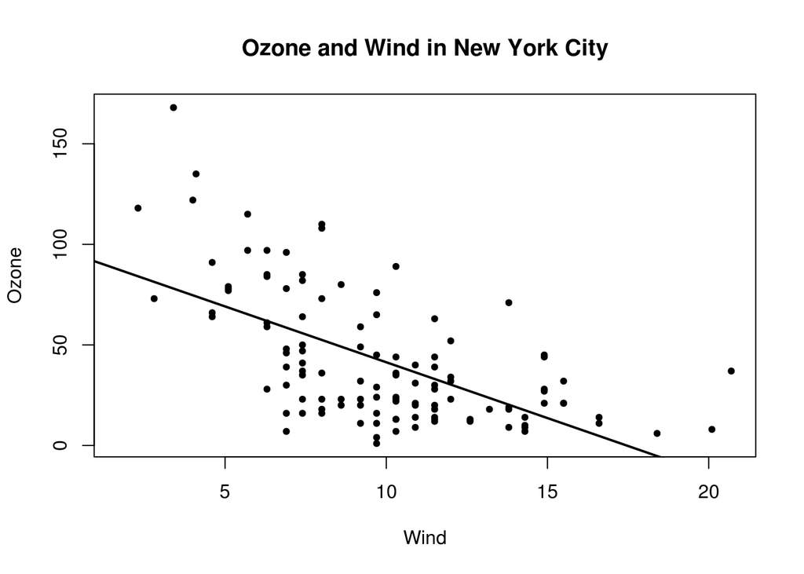

```r
with(airquality, plot(Wind, Ozone, main = "Ozone and Wind in New York City",
    pch = 20))
model <- lm(Ozone ~ Wind, airquality)
abline(model, lwd = 2)
```

**multiple plots**

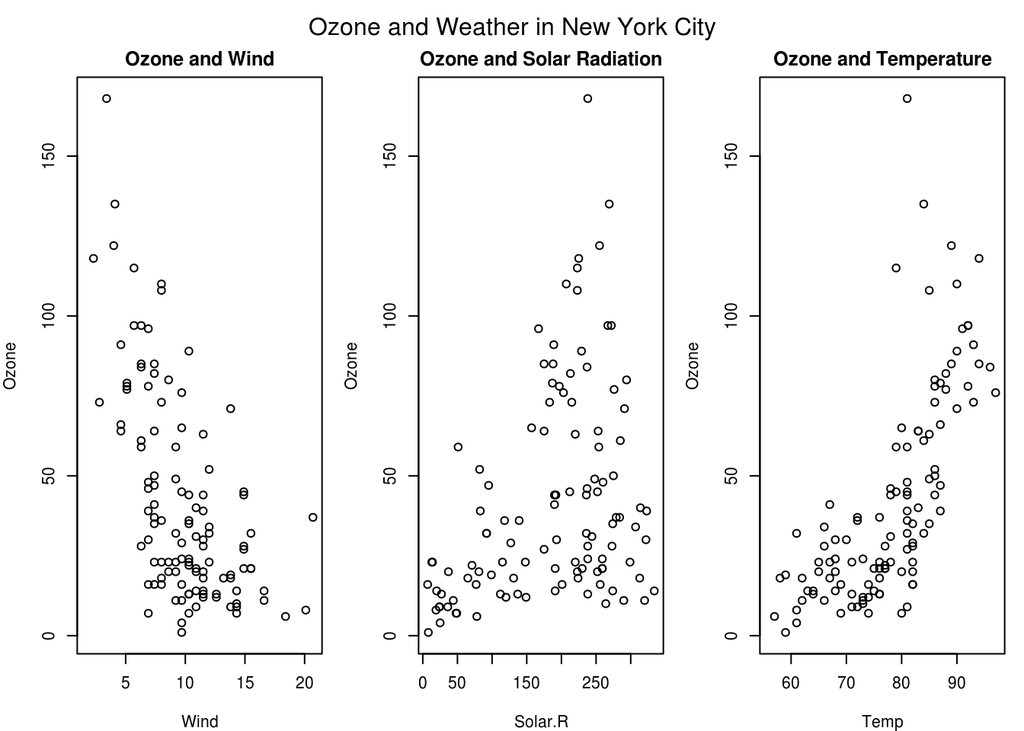

```r
par(mfrow = c(1, 2))
with(airquality, {
    plot(Wind, Ozone, main = "Ozone and Wind")
    plot(Solar.R, Ozone, main = "Ozone and Solar Radiation")
})
par(mfrow = c(1, 3), mar = c(4, 4, 2, 1), oma = c(0, 0, 2, 0))
with(airquality, {
    plot(Wind, Ozone, main = "Ozone and Wind")
    plot(Solar.R, Ozone, main = "Ozone and Solar Radiation")
    plot(Temp, Ozone, main = "Ozone and Temperature")
    mtext("Ozone and Weather in New York City", outer = TRUE)
})
```

2. Lattice

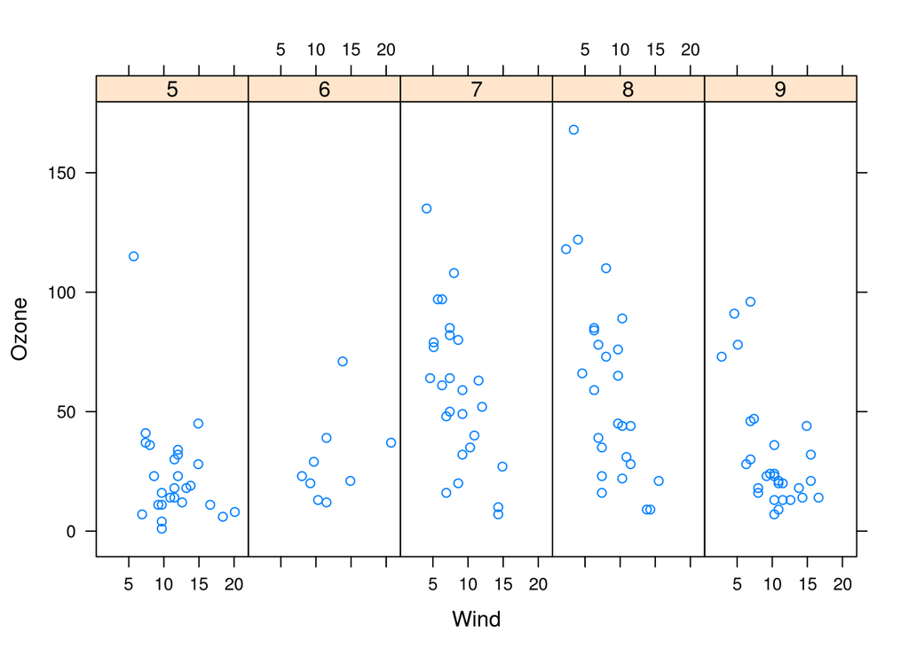

```r
library(lattice)
xyplot(Ozone ~ Wind | Month, data = airquality, layout = c(5, 1))
```

3. ggplot2

## qplot

```r
library(ggplot2)
str(mpg)
```

```
## Classes 'tbl_df', 'tbl' and 'data.frame':    234 obs. of  11 variables:
##  $ manufacturer: chr  "audi" "audi" "audi" "audi" ...
##  $ model       : chr  "a4" "a4" "a4" "a4" ...
##  $ displ       : num  1.8 1.8 2 2 2.8 2.8 3.1 1.8 1.8 2 ...
##  $ year        : int  1999 1999 2008 2008 1999 1999 2008 1999 1999 2008 ...
##  $ cyl         : int  4 4 4 4 6 6 6 4 4 4 ...
##  $ trans       : chr  "auto(l5)" "manual(m5)" "manual(m6)" "auto(av)" ...
##  $ drv         : chr  "f" "f" "f" "f" ...
##  $ cty         : int  18 21 20 21 16 18 18 18 16 20 ...
##  $ hwy         : int  29 29 31 30 26 26 27 26 25 28 ...
##  $ fl          : chr  "p" "p" "p" "p" ...
##  $ class       : chr  "compact" "compact" "compact" "compact" ...
```

**scatter plots**

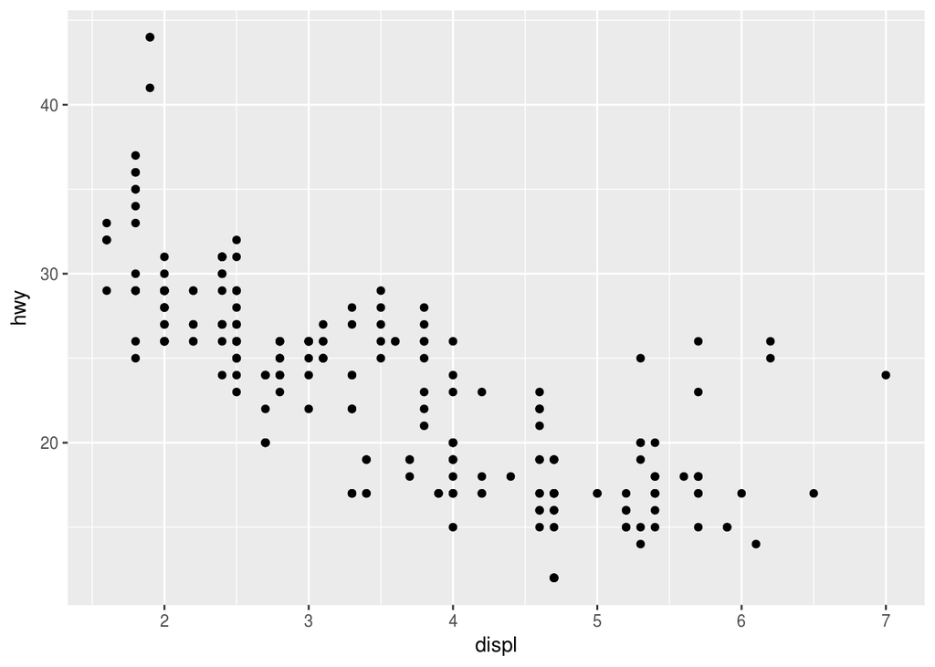

```r
qplot(displ, hwy, data = mpg)
```

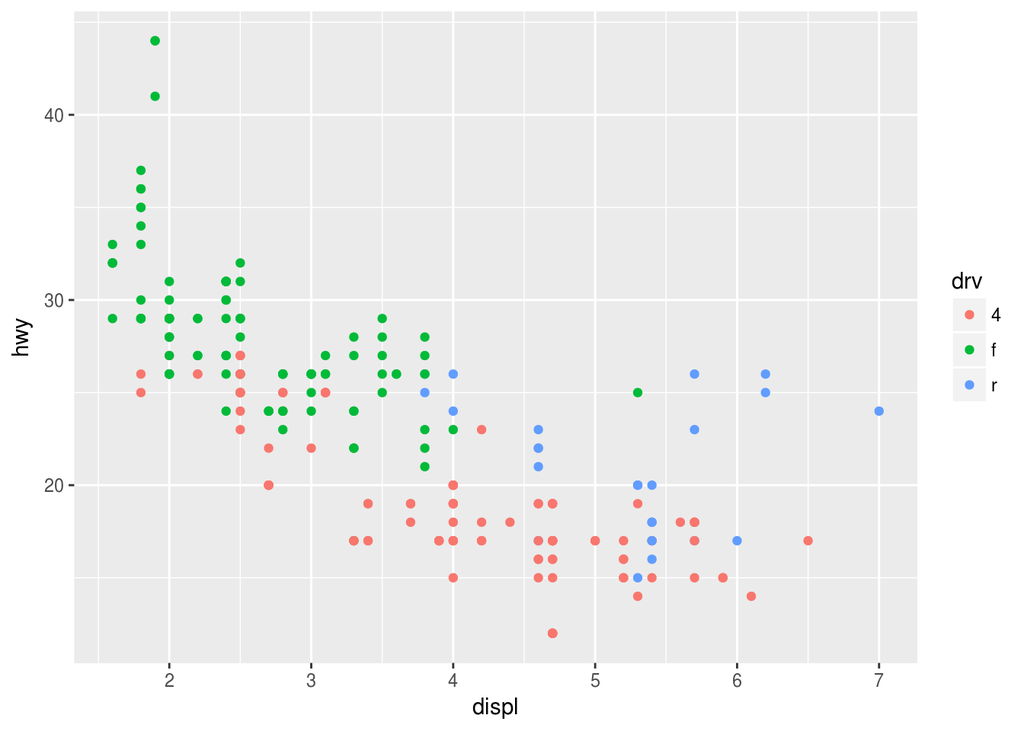

```r
qplot(displ, hwy, data = mpg, color = drv)
```

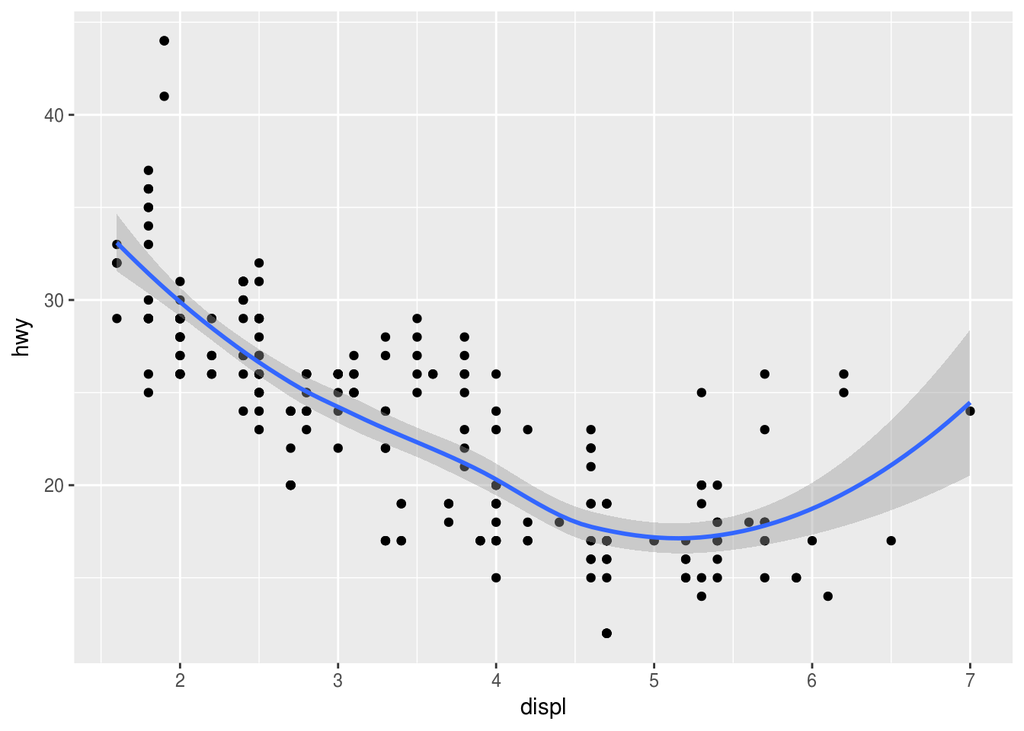

```r
qplot(displ, hwy, data = mpg, geom = c("point", "smooth"))
```

** histogram **

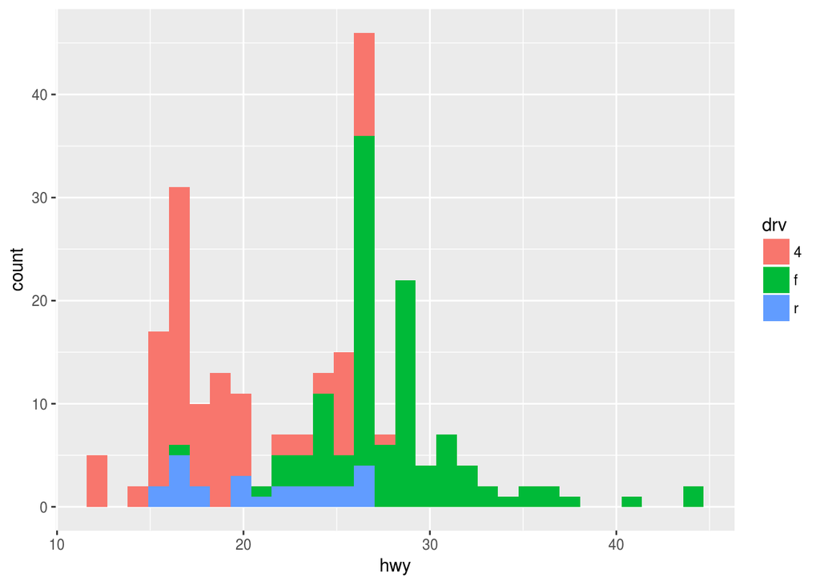

```r
qplot(hwy, data = mpg, fill = drv)
```

**facets**

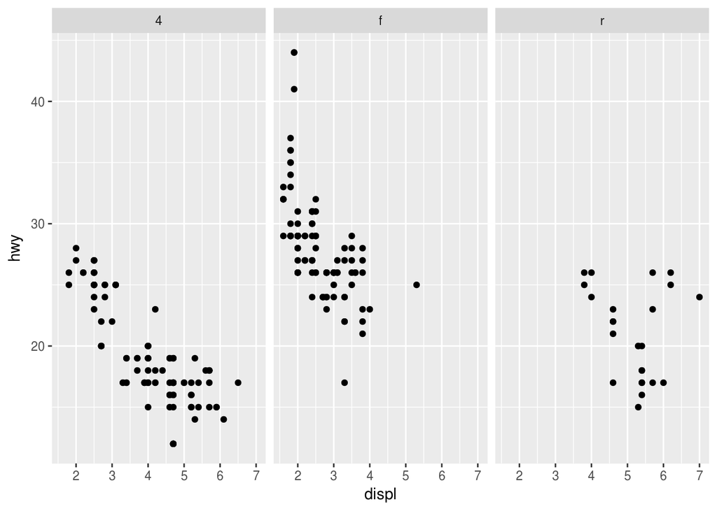

```r
qplot(displ, hwy, data = mpg, facets = . ~ drv)
```

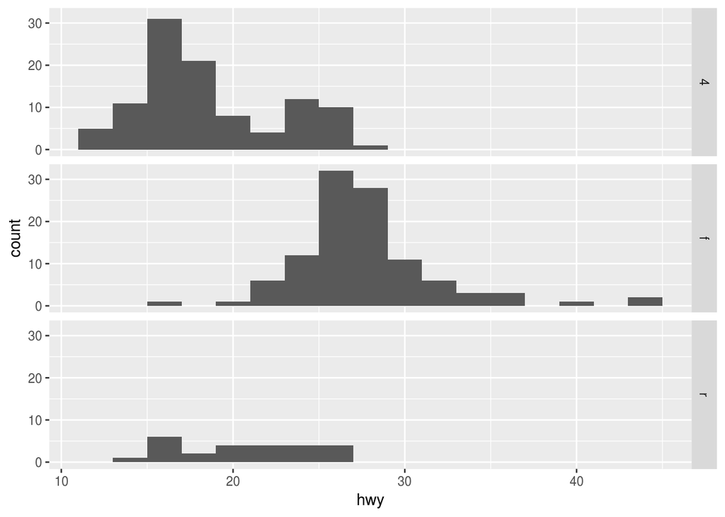

```r
qplot(hwy, data = mpg, facets = drv ~ ., binwidth = 2)
```

## GGPLOT2 GRAMMER

- A data frame
- aesthetic mappings: how data are mapped to color, size
- geoms: geometric objects like points, lines, shapes.
- facets: for conditional plots.
- stats: statistical transformations like binning, quantiles, smoothing.
- scales: what scale an aesthetic map uses (example: male = red, female = blue).
- coordinate system

## Clustering

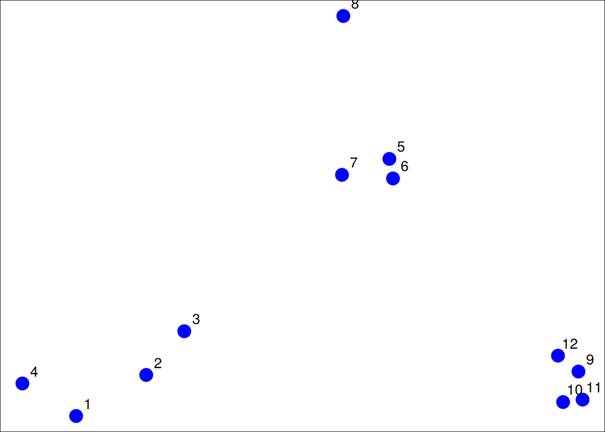

```r
set.seed(1234)
par(mar = c(0, 0, 0, 0))
x <- rnorm(12, mean = rep(1:3, each = 4), sd = 0.2)
y <- rnorm(12, mean = rep(c(1, 2, 1), each = 4), sd = 0.2)
plot(x, y, col = "blue", pch = 19, cex = 2)
text(x + 0.05, y + 0.05, labels = as.character(1:12))
```

** hclust **

** Distance or similarity for both hclust and kmeans** - Continuous - euclidean distance - Continous - correlation similarity - Binary - manhattan distance

Pick a distance/similarity that makes sense for your problem

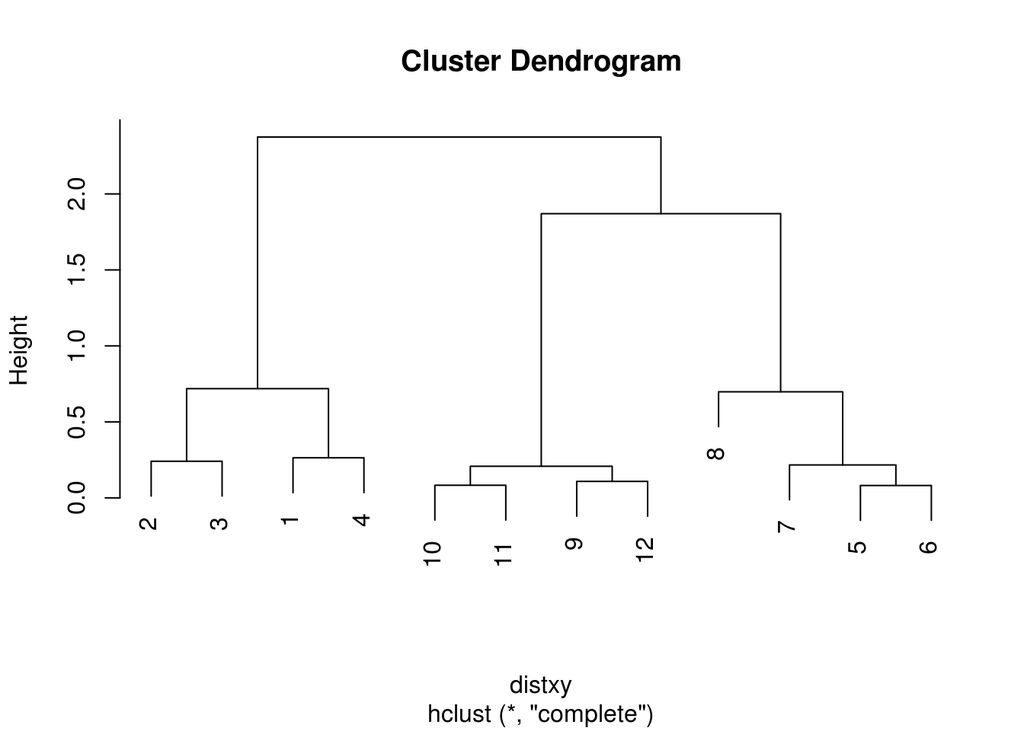

```r
dataFrame <- data.frame(x = x, y = y)
distxy <- dist(dataFrame,method = "euclidian")
hClustering <- hclust(distxy)
plot(hClustering)
```

Gives an idea of the relationships between variables/observations The picture may be unstable - Change a few points - Have different missing values - Pick a different distance - Change the merging strategy - Change the scale of points for one variable

But it is deterministic, Choosing where to cut isn’t always obvious, Should be primarily used for exploration

## K-means

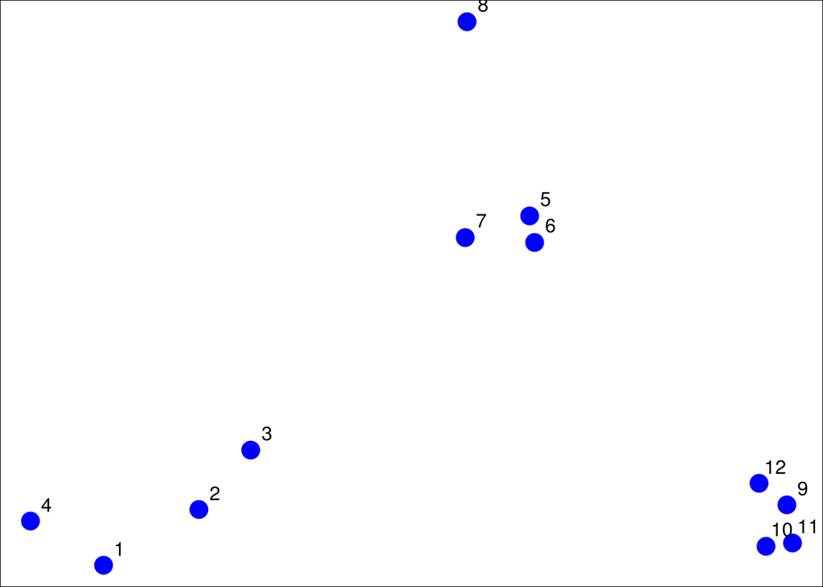

```r
set.seed(1234); par(mar=c(0,0,0,0))
x <- rnorm(12,mean=rep(1:3,each=4),sd=0.2)
y <- rnorm(12,mean=rep(c(1,2,1),each=4),sd=0.2)
plot(x,y,col="blue",pch=19,cex=2)
text(x+0.05,y+0.05,labels=as.character(1:12))
```

kmeans

```r
dataFrame <- data.frame(x,y)
kmeansObj <- kmeans(dataFrame,centers=3)
names(kmeansObj)
```

```
## [1] "cluster"      "centers"      "totss"        "withinss"
## [5] "tot.withinss" "betweenss"    "size"         "iter"
## [9] "ifault"
```

**plot**

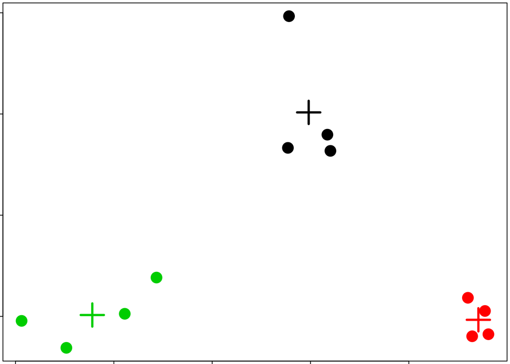

```r
par(mar=rep(0.2,4))
plot(x,y,col=kmeansObj$cluster,pch=19,cex=2)
points(kmeansObj$centers,col=1:3,pch=3,cex=3,lwd=3)
```

### Heatmaps

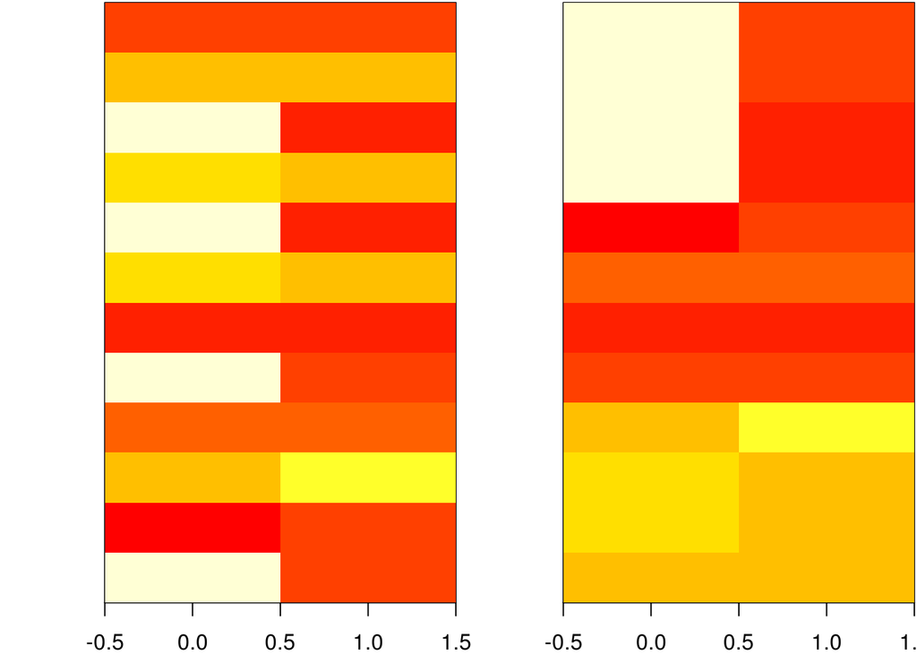

```r
set.seed(1234)
dataMatrix <- as.matrix(dataFrame)[sample(1:12),]
kmeansObj <- kmeans(dataMatrix,centers=3)
par(mfrow=c(1,2), mar = c(2, 4, 0.1, 0.1))
image(t(dataMatrix)[,nrow(dataMatrix):1],yaxt="n")
image(t(dataMatrix)[,order(kmeansObj$cluster)],yaxt="n")
```

# CLUSTERING

```r
load("~/mywork/JHU/data/samsungData.rda")
names(samsungData)[1:12]
```

```
##  [1] "tBodyAcc-mean()-X" "tBodyAcc-mean()-Y" "tBodyAcc-mean()-Z"
##  [4] "tBodyAcc-std()-X"  "tBodyAcc-std()-Y"  "tBodyAcc-std()-Z"
##  [7] "tBodyAcc-mad()-X"  "tBodyAcc-mad()-Y"  "tBodyAcc-mad()-Z"
## [10] "tBodyAcc-max()-X"  "tBodyAcc-max()-Y"  "tBodyAcc-max()-Z"
```

```r
head(samsungData$activity)
```

```
## [1] "standing" "standing" "standing" "standing" "standing" "standing"
```

```r
str(samsungData$activity)
```

```
##  chr [1:7352] "standing" "standing" "standing" "standing" ...
```

```r
table(samsungData$activity)
```

```
##
##   laying  sitting standing     walk walkdown   walkup
##     1407     1286     1374     1226      986     1073
```

** plotting average acceleration for first subject**

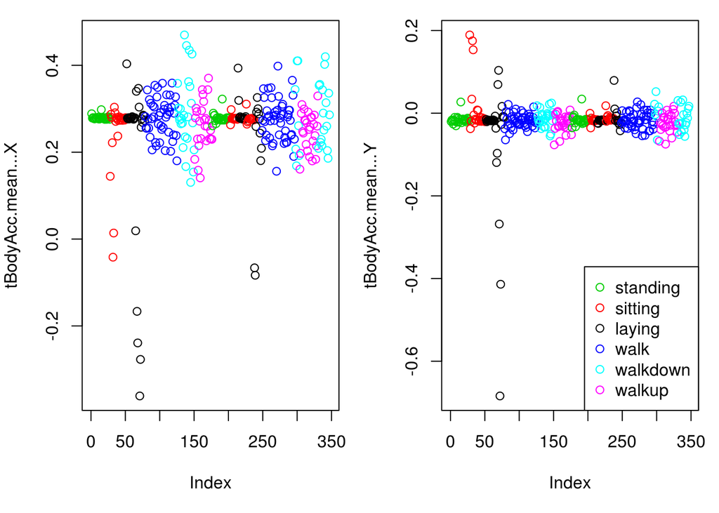

```r
par(mfrow = c(1, 2), mar = c(5, 4, 1, 1))
samsungData <- transform(samsungData, activity = factor(activity))
sub1 <- subset(samsungData, subject == 1)
plot(sub1[, 1], col = sub1$activity, ylab = names(sub1)[1])
plot(sub1[, 2], col = sub1$activity, ylab = names(sub1)[2])
legend("bottomright", legend = unique(sub1$activity), col = unique(sub1$activity),
    pch = 1)
```

## hclust

** clustering based on average acceleration**

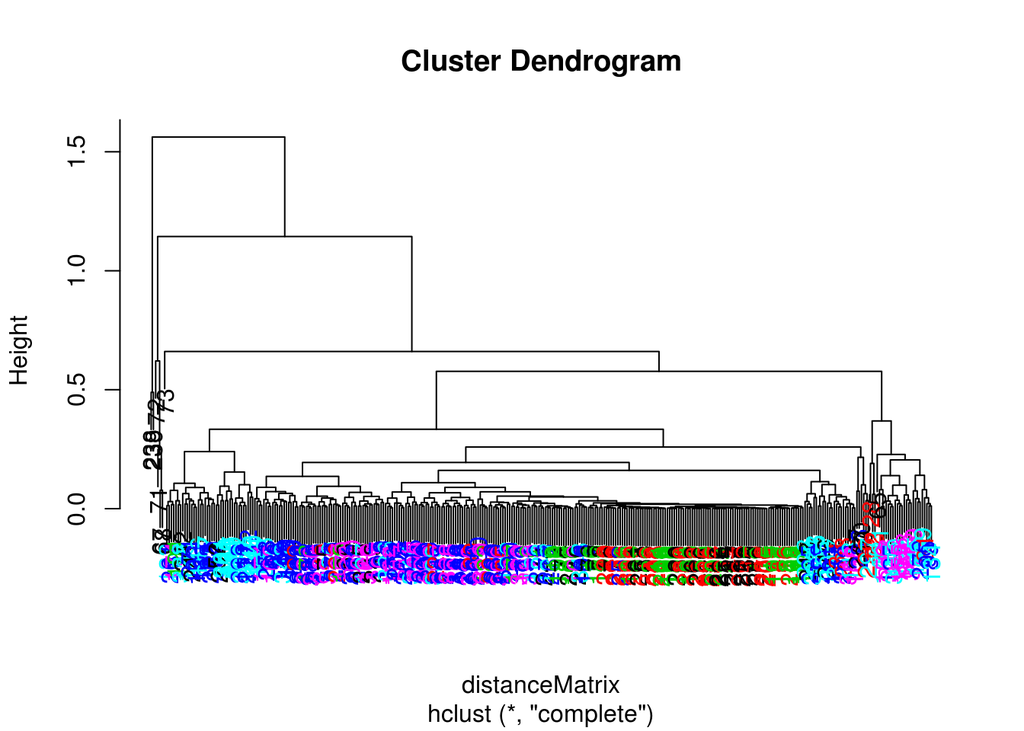

```r
par(mfrow = c(1,1))
myplclust <- function(hclust, lab = hclust$labels, lab.col = rep(1, length(hclust$labels)),
    hang = 0.1, ...) {
    ## modifiction of plclust for plotting hclust objects *in colour*!  Copyright
    ## Eva KF Chan 2009 Arguments: hclust: hclust object lab: a character vector
    ## of labels of the leaves of the tree lab.col: colour for the labels;
    ## NA=default device foreground colour hang: as in hclust & plclust Side
    ## effect: A display of hierarchical cluster with coloured leaf labels.
    y <- rep(hclust$height, 2)
    x <- as.numeric(hclust$merge)
    y <- y[which(x < 0)]
    x <- x[which(x < 0)]
    x <- abs(x)
    y <- y[order(x)]
    x <- x[order(x)]
    plot(hclust, labels = FALSE, hang = hang, ...)
    text(x = x, y = y[hclust$order] - (max(hclust$height) * hang), labels = lab[hclust$order],
        col = lab.col[hclust$order], srt = 90, adj = c(1, 0.5), xpd = NA, ...)
}
distanceMatrix <- dist(sub1[, 1:3])
hclustering <- hclust(distanceMatrix)
myplclust(hclustering, lab.col = unclass(sub1$activity))
```

*not much of seperation with various activities, which is deduced from mix of all the colors in the bottom of graph*

** plotting max acceleration **

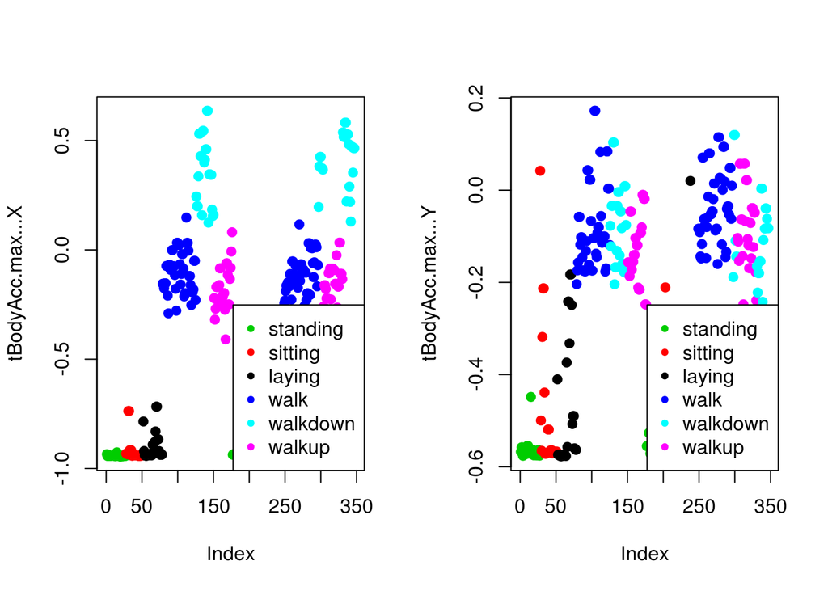

```r
par(mfrow = c(1, 2))
plot(sub1[, 10], pch = 19, col = sub1$activity, ylab = names(sub1)[10])
legend("bottomright", legend = unique(sub1$activity), col = unique(sub1$activity),
    pch = 20)
plot(sub1[, 11], pch = 19, col = sub1$activity, ylab = names(sub1)[11])
legend("bottomright", legend = unique(sub1$activity), col = unique(sub1$activity),
    pch = 20)
```

```r
par(mfrow = c(1,1))
```

** clustering based on max acceleleration **

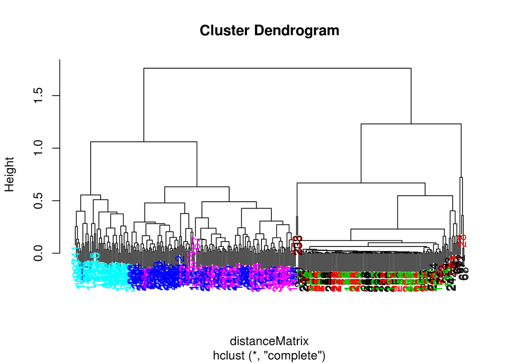

```r
distanceMatrix <- dist(sub1[, 10:12])
hclustering <- hclust(distanceMatrix)
myplclust(hclustering, lab.col = unclass(sub1$activity))
```

*seperated out walking activities and unmoving activities*

** singular value decomposition **

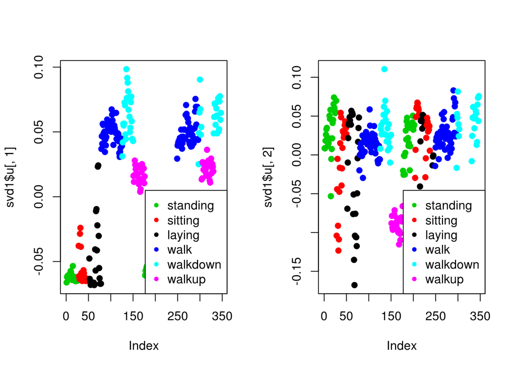

```r
svd1 = svd(scale(sub1[, -c(562, 563)]))
par(mfrow = c(1, 2))
plot(svd1$u[, 1], col = sub1$activity, pch = 19)
legend("bottomright", legend = unique(sub1$activity), col = unique(sub1$activity),
    pch = 20)
plot(svd1$u[, 2], col = sub1$activity, pch = 19)
legend("bottomright", legend = unique(sub1$activity), col = unique(sub1$activity),
    pch = 20)
```

** finding maximum contributor**

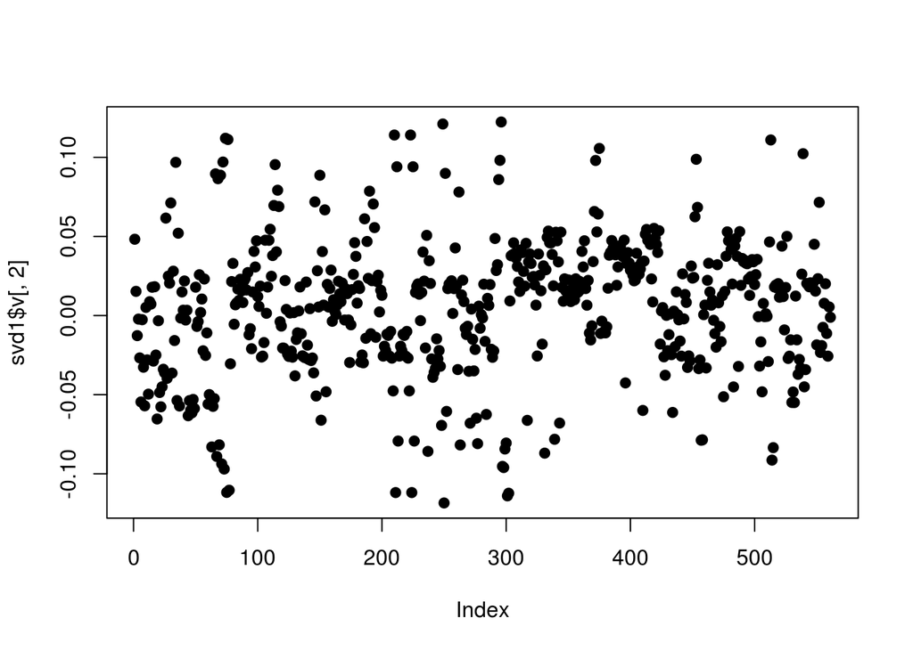

```r
plot(svd1$v[, 2], pch = 19)
```

```r
maxContrib <- which.max(svd1$v[, 2])
```

** clustering based on maximum contributor **

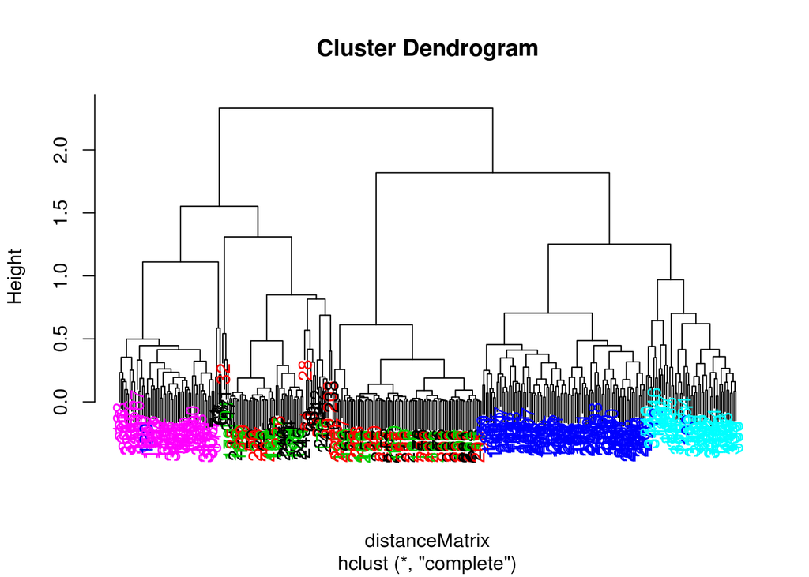

```r
distanceMatrix <- dist(sub1[, c(10:12, maxContrib)])
hclustering <- hclust(distanceMatrix)
myplclust(hclustering, lab.col = unclass(sub1$activity))
```

** maximum contributor **

```r
names(samsungData)[maxContrib]
```

```
## [1] "fBodyAcc.meanFreq...Z"
```

*adding the maximun contributor to clustering helped in additonal seperation between walking activities, which non moving activities are still not seperated*

## Kmeans

** nstart=1 first try **

```r
kClust <- kmeans(sub1[, -c(562, 563)], centers = 6)
table(kClust$cluster, sub1$activity)
```

```
##
##     laying sitting standing walk walkdown walkup
##   1      0       0        0    0       26      0
##   2      0       0        0    0       23      0
##   3      0       0        0   27        0      0
##   4     42      45       53    0        0      0
##   5      8       2        0    0        0     53
##   6      0       0        0   68        0      0
```

** nstart =1 second try **

```r
kClust <- kmeans(sub1[, -c(562, 563)], centers = 6, nstart = 1)
table(kClust$cluster, sub1$activity)
```

```
##
##     laying sitting standing walk walkdown walkup
##   1      0       0        0    0        0     53
##   2     27       0        0    0        0      0
##   3      0      34       50    0        0      0
##   4     14      11        3    0        0      0
##   5      0       0        0   95       49      0
##   6      9       2        0    0        0      0
```

** nstart 100 1st try **

```r
kClust <- kmeans(sub1[, -c(562, 563)], centers = 6, nstart = 100)
table(kClust$cluster, sub1$activity)
```

```
##
##     laying sitting standing walk walkdown walkup
##   1     18      10        2    0        0      0
##   2      0       0        0    0       49      0
##   3      0      37       51    0        0      0
##   4      0       0        0   95        0      0
##   5     29       0        0    0        0      0
##   6      3       0        0    0        0     53
```

** nstart 100 second try **

```r
kClust <- kmeans(sub1[, -c(562, 563)], centers = 6, nstart = 100)
table(kClust$cluster, sub1$activity)
```

```
##
##     laying sitting standing walk walkdown walkup
##   1      0      37       51    0        0      0
##   2      0       0        0    0       49      0
##   3     18      10        2    0        0      0
##   4     29       0        0    0        0      0
##   5      0       0        0   95        0      0
##   6      3       0        0    0        0     53
```

** cluster1 variable centering **

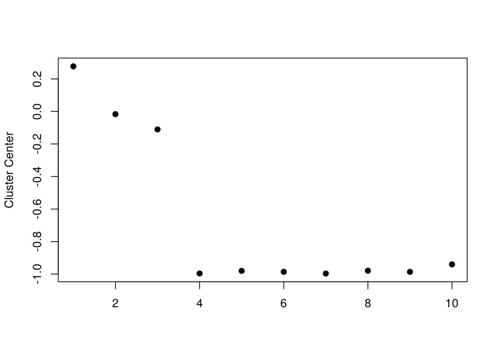

```r
plot(kClust$center[1, 1:10], pch = 19, ylab = "Cluster Center", xlab = "")
```

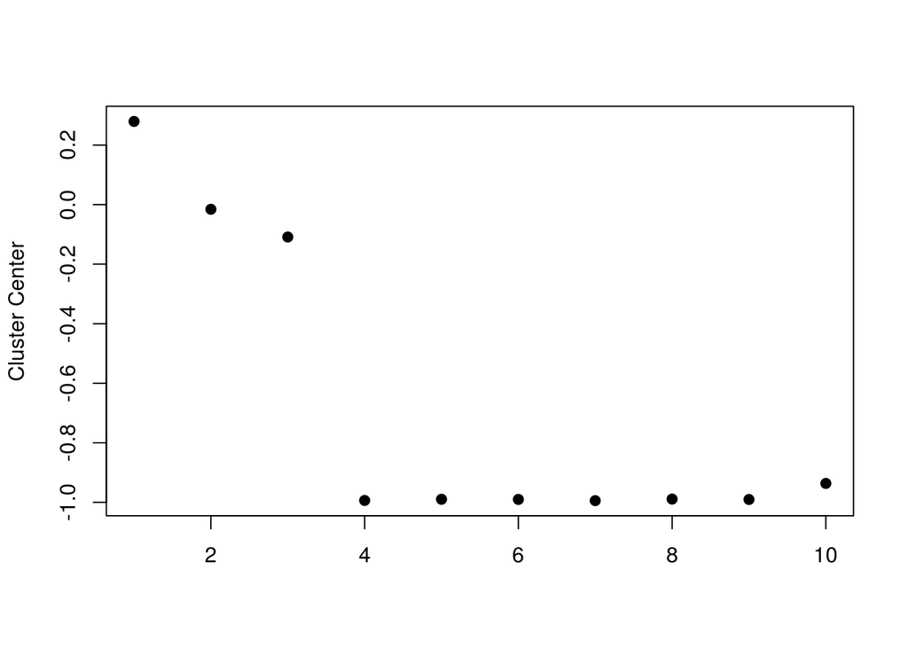

```r
plot(kClust$center[4, 1:10], pch = 19, ylab = "Cluster Center", xlab = "")
```

# Air pollution

## Has fine particle pollution in the U.S. decreased from 1999 to 2012?

## Read in data from 1999

```r
pm0 <- read.table("~/mywork/JHU/data/RD_501_88101_1999-0.txt", comment.char = "#", header = FALSE, sep = "|", na.strings = "")
dim(pm0)
```

```
## [1] 117421     28
```

```r
head(pm0)
```

```
##   V1 V2 V3 V4 V5    V6 V7 V8  V9 V10      V11   V12    V13  V14 V15 V16
## 1 RD  I  1 27  1 88101  1  7 105 120 19990103 00:00     NA   AS   3  NA
## 2 RD  I  1 27  1 88101  1  7 105 120 19990106 00:00     NA   AS   3  NA
## 3 RD  I  1 27  1 88101  1  7 105 120 19990109 00:00     NA   AS   3  NA
## 4 RD  I  1 27  1 88101  1  7 105 120 19990112 00:00  8.841 <NA>   3  NA
## 5 RD  I  1 27  1 88101  1  7 105 120 19990115 00:00 14.920 <NA>   3  NA
## 6 RD  I  1 27  1 88101  1  7 105 120 19990118 00:00  3.878 <NA>   3  NA
##    V17 V18 V19 V20 V21 V22 V23 V24 V25 V26 V27 V28
## 1 <NA>  NA  NA  NA  NA  NA  NA  NA  NA  NA  NA  NA
## 2 <NA>  NA  NA  NA  NA  NA  NA  NA  NA  NA  NA  NA
## 3 <NA>  NA  NA  NA  NA  NA  NA  NA  NA  NA  NA  NA
## 4 <NA>  NA  NA  NA  NA  NA  NA  NA  NA  NA  NA  NA
## 5 <NA>  NA  NA  NA  NA  NA  NA  NA  NA  NA  NA  NA
## 6 <NA>  NA  NA  NA  NA  NA  NA  NA  NA  NA  NA  NA
```

```r
cnames <- readLines("~/mywork/JHU/data/RD_501_88101_1999-0.txt", 1)
print(cnames)
```

```
## [1] "# RD|Action Code|State Code|County Code|Site ID|Parameter|POC|Sample Duration|Unit|Method|Date|Start Time|Sample Value|Null Data Code|Sampling Frequency|Monitor Protocol (MP) ID|Qualifier - 1|Qualifier - 2|Qualifier - 3|Qualifier - 4|Qualifier - 5|Qualifier - 6|Qualifier - 7|Qualifier - 8|Qu…
```

```r
cnames <- strsplit(cnames, "|", fixed = TRUE)
print(cnames)
```

```
## [[1]]
##  [1] "# RD"
##  [2] "Action Code"
##  [3] "State Code"
##  [4] "County Code"
##  [5] "Site ID"
##  [6] "Parameter"
##  [7] "POC"
##  [8] "Sample Duration"
##  [9] "Unit"
## [10] "Method"
## [11] "Date"
## [12] "Start Time"
## [13] "Sample Value"
## [14] "Null Data Code"
## [15] "Sampling Frequency"
## [16] "Monitor Protocol (MP) ID"
## [17] "Qualifier - 1"
## [18] "Qualifier - 2"
## [19] "Qualifier - 3"
## [20] "Qualifier - 4"
## [21] "Qualifier - 5"
## [22] "Qualifier - 6"
## [23] "Qualifier - 7"
## [24] "Qualifier - 8"
## [25] "Qualifier - 9"
## [26] "Qualifier - 10"
## [27] "Alternate Method Detectable Limit"
## [28] "Uncertainty"
```

```r
names(pm0) <- make.names(cnames[[1]])
head(pm0)
```

```
##   X..RD Action.Code State.Code County.Code Site.ID Parameter POC
## 1    RD           I          1          27       1     88101   1
## 2    RD           I          1          27       1     88101   1
## 3    RD           I          1          27       1     88101   1
## 4    RD           I          1          27       1     88101   1
## 5    RD           I          1          27       1     88101   1
## 6    RD           I          1          27       1     88101   1
##   Sample.Duration Unit Method     Date Start.Time Sample.Value
## 1               7  105    120 19990103      00:00           NA
## 2               7  105    120 19990106      00:00           NA
## 3               7  105    120 19990109      00:00           NA
## 4               7  105    120 19990112      00:00        8.841
## 5               7  105    120 19990115      00:00       14.920
## 6               7  105    120 19990118      00:00        3.878
##   Null.Data.Code Sampling.Frequency Monitor.Protocol..MP..ID Qualifier...1
```

[output cut: 27 more lines]

```r
x0 <- pm0$Sample.Value
class(x0)
```

```
## [1] "numeric"
```

```r
str(x0)
```

```
##  num [1:117421] NA NA NA 8.84 14.92 ...
```

```r
summary(x0)
```

```
##    Min. 1st Qu.  Median    Mean 3rd Qu.    Max.    NA's
##    0.00    7.20   11.50   13.74   17.90  157.10   13217
```

```r
mean(is.na(x0))
```

```
## [1] 0.1125608
```

### Are missing values important here?

## Read in data from 2012

```r
pm1 <- read.table("~/mywork/JHU/data/RD_501_88101_2012-0.txt", comment.char = "#", header = FALSE, sep = "|", na.strings = "", nrow = 1304290)
names(pm1) <- make.names(cnames[[1]])
head(pm1)
```

```
##   X..RD Action.Code State.Code County.Code Site.ID Parameter POC
## 1    RD           I          1           3      10     88101   1
## 2    RD           I          1           3      10     88101   1
## 3    RD           I          1           3      10     88101   1
## 4    RD           I          1           3      10     88101   1
## 5    RD           I          1           3      10     88101   1
## 6    RD           I          1           3      10     88101   1
##   Sample.Duration Unit Method     Date Start.Time Sample.Value
## 1               7  105    118 20120101      00:00          6.7
## 2               7  105    118 20120104      00:00          9.0
## 3               7  105    118 20120107      00:00          6.5
## 4               7  105    118 20120110      00:00          7.0
## 5               7  105    118 20120113      00:00          5.8
## 6               7  105    118 20120116      00:00          8.0
##   Null.Data.Code Sampling.Frequency Monitor.Protocol..MP..ID Qualifier...1
```

[output cut: 27 more lines]

```r
dim(pm1)
```

```
## [1] 1304287      28
```

```r
x1 <- pm1$Sample.Value
class(x1)
```

```
## [1] "numeric"
```

### Five number summaries for both periods

```r
summary(x1)
```

```
##    Min. 1st Qu.  Median    Mean 3rd Qu.    Max.    NA's
##  -10.00    4.00    7.63    9.14   12.00  909.00   73133
```

```r
summary(x0)
```

```
##    Min. 1st Qu.  Median    Mean 3rd Qu.    Max.    NA's
##    0.00    7.20   11.50   13.74   17.90  157.10   13217
```

```r
mean(is.na(x1))
```

```
## [1] 0.05607125
```

### Are missing values important here?

### Make a boxplot of both 1999 and 2012

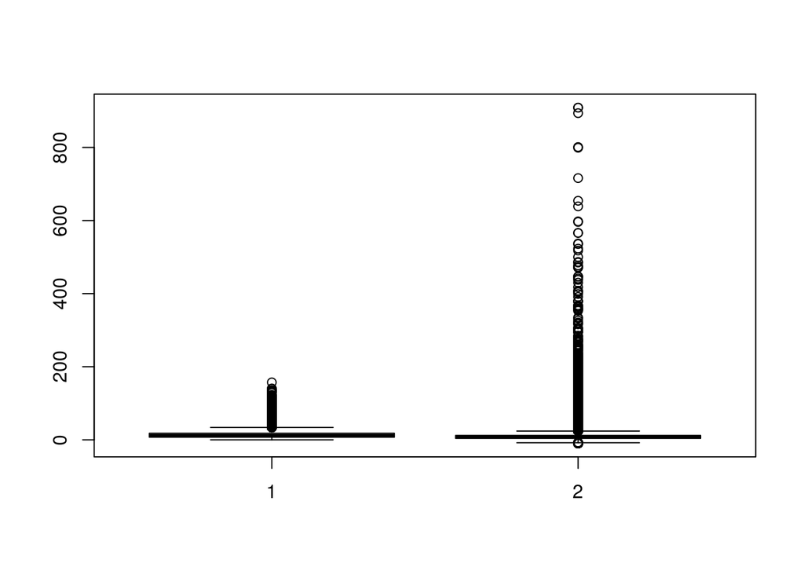

```r
boxplot(x0, x1)
```

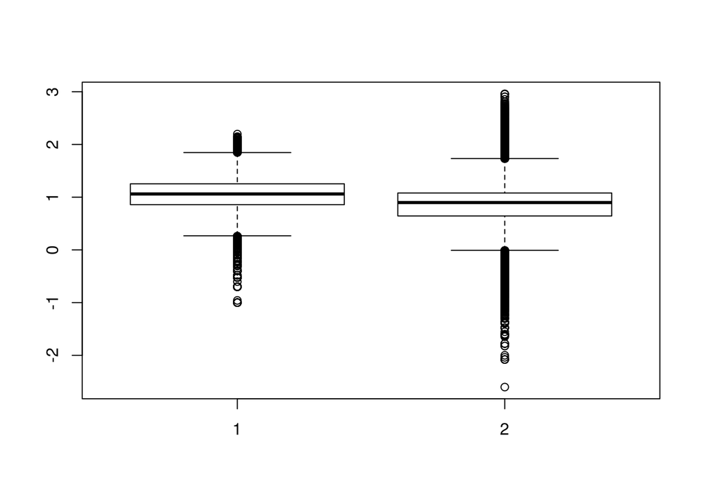

```r
boxplot(log10(x0), log10(x1))
```

### Check negative values in ‘x1’

```r
summary(x1)
```

```
##    Min. 1st Qu.  Median    Mean 3rd Qu.    Max.    NA's
##  -10.00    4.00    7.63    9.14   12.00  909.00   73133
```

```r
negative <- x1 < 0
sum(negative, na.rm = T)
```

```
## [1] 26474
```

```r
mean(negative, na.rm = T)
```

```
## [1] 0.0215034
```

```r
dates <- pm1$Date
str(dates)
```

```
##  int [1:1304287] 20120101 20120104 20120107 20120110 20120113 20120116 20120119 20120122 20120125 20120128 ...
```

```r
dates <- as.Date(as.character(dates), "%Y%m%d")
str(dates)
```

```
##  Date[1:1304287], format: "2012-01-01" "2012-01-04" "2012-01-07" "2012-01-10" ...
```

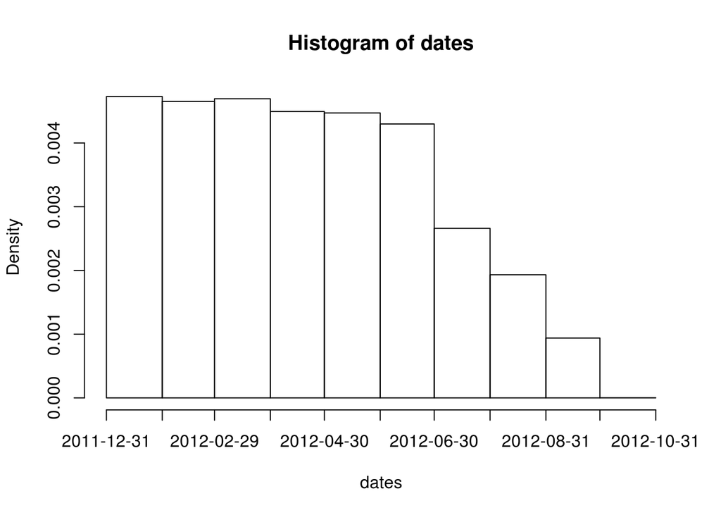

```r
hist(dates, "month")
```

### Plot a subset for one monitor at both times

### Find a monitor for New York State that exists in both datasets

```r
site0 <- unique(subset(pm0, State.Code == 36, c(County.Code, Site.ID)))
site1 <- unique(subset(pm1, State.Code == 36, c(County.Code, Site.ID)))
site0 <- paste(site0[,1], site0[,2], sep = ".")
site1 <- paste(site1[,1], site1[,2], sep = ".")
str(site0)
```

```
##  chr [1:33] "1.5" "1.12" "5.73" "5.80" "5.83" "5.110" ...
```

```r
str(site1)
```

```
##  chr [1:18] "1.5" "1.12" "5.80" "5.133" "13.11" "29.5" ...
```

```r
both <- intersect(site0, site1)
print(both)
```

```
##  [1] "1.5"     "1.12"    "5.80"    "13.11"   "29.5"    "31.3"    "63.2008"
##  [8] "67.1015" "85.55"   "101.3"
```

### Find how many observations available at each monitor

```r
pm0$county.site <- with(pm0, paste(County.Code, Site.ID, sep = "."))
pm1$county.site <- with(pm1, paste(County.Code, Site.ID, sep = "."))
cnt0 <- subset(pm0, State.Code == 36 & county.site %in% both)
cnt1 <- subset(pm1, State.Code == 36 & county.site %in% both)
sapply(split(cnt0, cnt0$county.site), nrow)
```

```
##   101.3    1.12   13.11     1.5    29.5    31.3    5.80 63.2008 67.1015
##     152      61      61     122      61     183      61     122     122
##   85.55
##       7
```

```r
sapply(split(cnt1, cnt1$county.site), nrow)
```

```
##   101.3    1.12   13.11     1.5    29.5    31.3    5.80 63.2008 67.1015
##      31      31      31      64      33      15      31      30      31
##   85.55
##      31
```

### Choose county 63 and side ID 2008

```r
pm1sub <- subset(pm1, State.Code == 36 & County.Code == 63 & Site.ID == 2008)
pm0sub <- subset(pm0, State.Code == 36 & County.Code == 63 & Site.ID == 2008)
dim(pm1sub)
```

```
## [1] 30 29
```

```r
dim(pm0sub)
```

```
## [1] 122  29
```

### Plot data for 2012

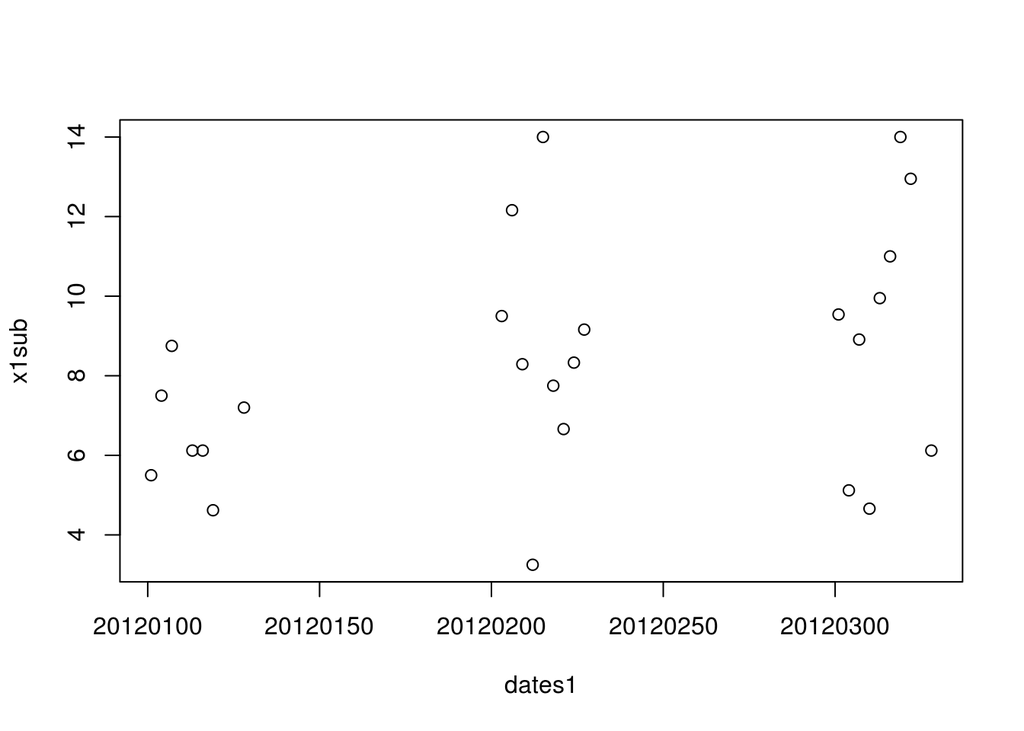

```r
dates1 <- pm1sub$Date
x1sub <- pm1sub$Sample.Value
plot(dates1, x1sub)
```

```r
dates1 <- as.Date(as.character(dates1), "%Y%m%d")
str(dates1)
```

```
##  Date[1:30], format: "2012-01-01" "2012-01-04" "2012-01-07" "2012-01-10" ...
```

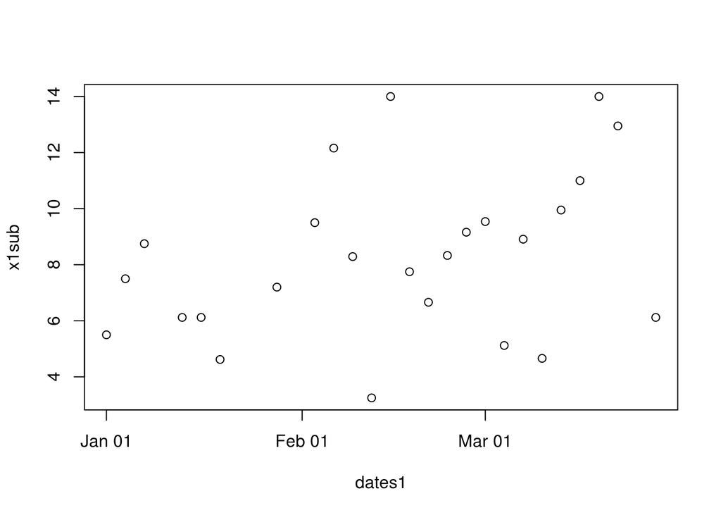

```r
plot(dates1, x1sub)
```

### Plot data for 1999

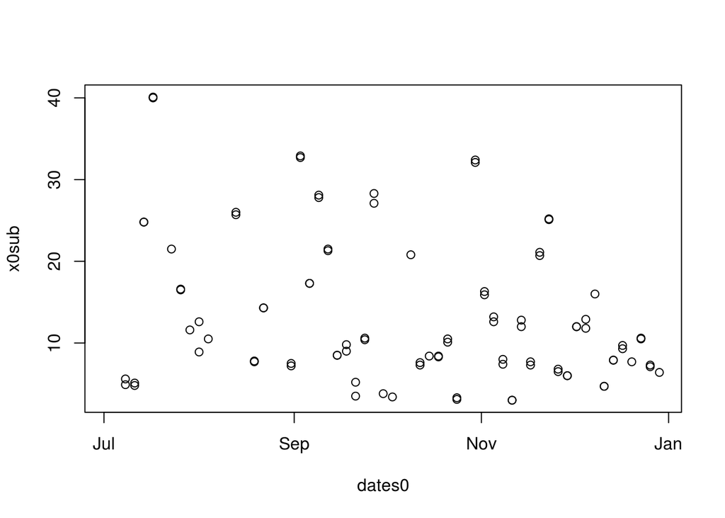

```r
dates0 <- pm0sub$Date
dates0 <- as.Date(as.character(dates0), "%Y%m%d")
x0sub <- pm0sub$Sample.Value
plot(dates0, x0sub)
```

### Plot data for both years in same panel

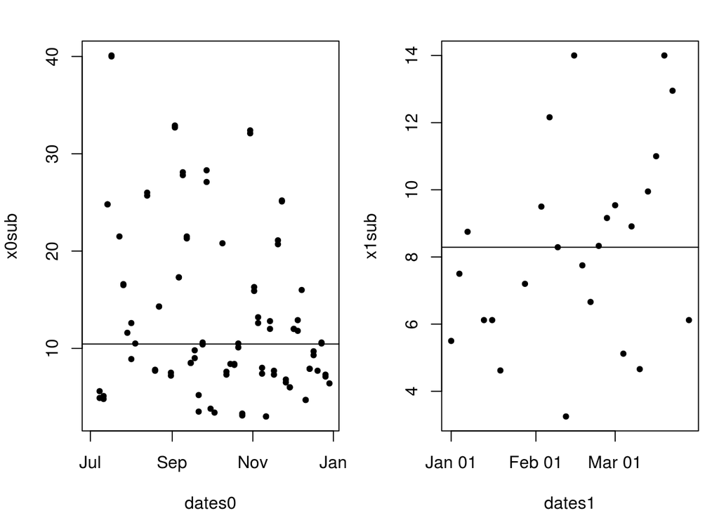

```r
par(mfrow = c(1, 2), mar = c(4, 4, 2, 1))
plot(dates0, x0sub, pch = 20)
abline(h = median(x0sub, na.rm = T))
plot(dates1, x1sub, pch = 20)  ## Whoa! Different ranges
abline(h = median(x1sub, na.rm = T))
```

### Find global range

```r
rng <- range(x0sub, x1sub, na.rm = T)
rng
```

```
## [1]  3.0 40.1
```

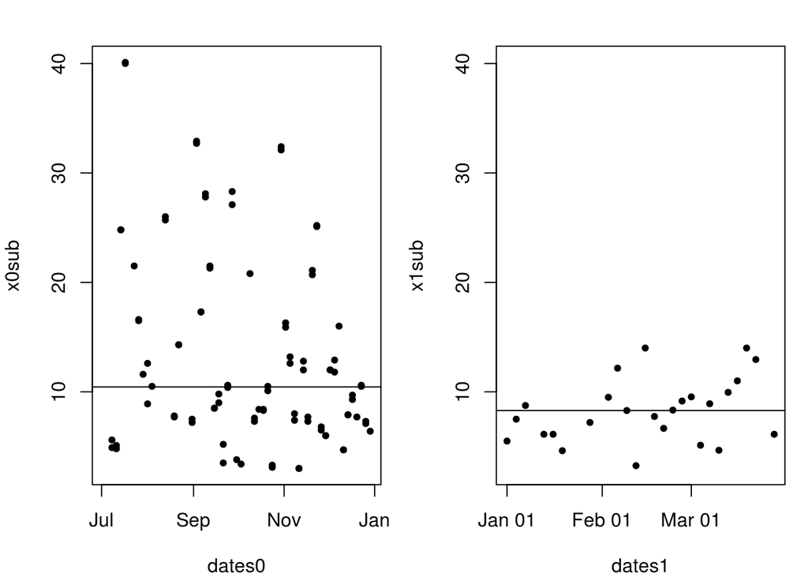

```r
par(mfrow = c(1, 2), mar = c(4, 4, 2, 1))
plot(dates0, x0sub, pch = 20, ylim = rng)
abline(h = median(x0sub, na.rm = T))
plot(dates1, x1sub, pch = 20, ylim = rng)
abline(h = median(x1sub, na.rm = T))
```

### Show state-wide means and make a plot showing trend

```r
head(pm0)
```

```
##   X..RD Action.Code State.Code County.Code Site.ID Parameter POC
## 1    RD           I          1          27       1     88101   1
## 2    RD           I          1          27       1     88101   1
## 3    RD           I          1          27       1     88101   1
## 4    RD           I          1          27       1     88101   1
## 5    RD           I          1          27       1     88101   1
## 6    RD           I          1          27       1     88101   1
##   Sample.Duration Unit Method     Date Start.Time Sample.Value
## 1               7  105    120 19990103      00:00           NA
## 2               7  105    120 19990106      00:00           NA
## 3               7  105    120 19990109      00:00           NA
## 4               7  105    120 19990112      00:00        8.841
## 5               7  105    120 19990115      00:00       14.920
## 6               7  105    120 19990118      00:00        3.878
##   Null.Data.Code Sampling.Frequency Monitor.Protocol..MP..ID Qualifier...1
```

[output cut: 27 more lines]

```r
mn0 <- with(pm0, tapply(Sample.Value, State.Code, mean, na.rm = T))
str(mn0)
```

```
##  num [1:53(1d)] 19.96 6.67 10.8 15.68 17.66 ...
##  - attr(*, "dimnames")=List of 1
##   ..$ : chr [1:53] "1" "2" "4" "5" ...
```

```r
summary(mn0)
```

```
##    Min. 1st Qu.  Median    Mean 3rd Qu.    Max.
##   4.862   9.519  12.310  12.410  15.640  19.960
```

```r
mn1 <- with(pm1, tapply(Sample.Value, State.Code, mean, na.rm = T))
str(mn1)
```

```
##  num [1:52(1d)] 10.13 4.75 8.61 10.56 9.28 ...
##  - attr(*, "dimnames")=List of 1
##   ..$ : chr [1:52] "1" "2" "4" "5" ...
```

```r
names(mn0)
```

```
##  [1] "1"  "2"  "4"  "5"  "6"  "8"  "9"  "10" "11" "12" "13" "15" "16" "17"
## [15] "18" "19" "20" "21" "22" "23" "24" "25" "26" "27" "28" "29" "30" "31"
## [29] "32" "33" "34" "35" "36" "37" "38" "39" "40" "41" "42" "44" "45" "46"
## [43] "47" "48" "49" "50" "51" "53" "54" "55" "56" "72" "78"
```

```r
names(mn1)
```

```
##  [1] "1"  "2"  "4"  "5"  "6"  "8"  "9"  "10" "11" "12" "13" "15" "16" "17"
## [15] "18" "19" "20" "21" "22" "23" "24" "25" "26" "27" "28" "29" "30" "31"
## [29] "32" "33" "34" "35" "36" "37" "38" "39" "40" "41" "42" "44" "45" "46"
## [43] "47" "48" "49" "50" "51" "53" "54" "55" "56" "72"
```

### Make separate data frames for states / years

```r
d0 <- data.frame(state = names(mn0), mean = mn0)
d1 <- data.frame(state = names(mn1), mean = mn1)
mrg <- merge(d0, d1, by = "state")
dim(mrg)
```

```
## [1] 52  3
```

```r
head(mrg)
```

```
##   state    mean.x    mean.y
## 1     1 19.956391 10.126190
## 2    10 14.492895 11.236059
## 3    11 15.786507 11.991697
## 4    12 11.137139  8.239690
## 5    13 19.943240 11.321364
## 6    15  4.861821  8.749336
```

## Connect lines

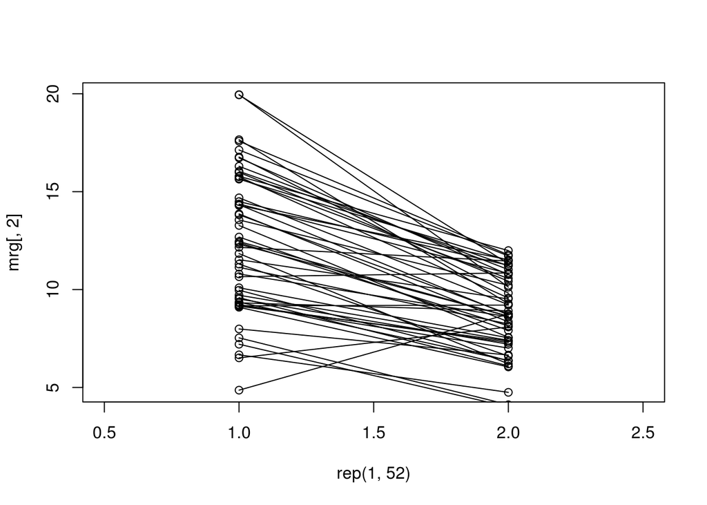

```r
par(mfrow = c(1, 1))
with(mrg, plot(rep(1, 52), mrg[, 2], xlim = c(.5, 2.5)))
with(mrg, points(rep(2, 52), mrg[, 3]))
segments(rep(1, 52), mrg[, 2], rep(2, 52), mrg[, 3])
```